# Lesson5-SpatialData

Aaron Mamula

2024-08-07

# Intro

This lesson is a very simple introduction to working with spatially explicit data using the [Simple Features for R Library](https://r-spatial.github.io/sf/articles/sf1.html). My coverage of this topic will be strictly mechanical, focused on giving you the minimum viable unit of code needed to make a simple, yet interesting, map. If you plan on doing any real analytical work with georeferenced data you will need to understand some fairly complicated geostatistical and cartographic concepts. Here are a few resources you may want to consider jumpstarting your journey with:

- [What is a shapefile?](https://www.usna.edu/Users/oceano/pguth/md_help/html/shapefile.htm)
- [Why are projections important?](https://desktop.arcgis.com/en/arcmap/latest/map/projections/projection-basics-for-gis-professionals.htm)
- [What is a spatial reference system?](https://en.wikipedia.org/wiki/Spatial_reference_system)

# Dependencies

The main new library we will be working with here is the `sf` library. `sf` stands for simple features and it is a very power, yet relatively easy to use, R package for dealing with spatial data.

I will also use the `viridis` library to make the final data visualization product. The `viridis` library is a color palette package that works well with `ggplot2` and provides easy access to several colorblind-friendly color schemes.

```r
library(sf)
library(dplyr)
library(ggplot2)
library(here)
library(viridis)
```

# Data

There are 3 external data files you will need for this lesson:

1. A county boundary shapefile which I have added to the [google drive here](https://drive.google.com/drive/folders/1wY79XVlcGHRULjsBbWWpVkhRKgq4i43l?usp=drive_link). The county boundary shapefile library is not included in the GitHub repository because it is prohibitively large. You will need to download the entire folder and keep the individual files together. There should be 7 files in the folder called `tl_2020-us_county`. You’ll need to copy this entire folder from the google drive to a local directory on your computer.
2. A county population data file for California counties which is in the [Github repository](https://github.com/aaronmams/HPP-R-Group-2023/blob/master/Data/county_pop.csv).
3. A county-level data file containing covid cases and deaths organized by date and county for U.S. counties. These data are also included in the [Github Repository](https://github.com/aaronmams/HPP-R-Group-2023/blob/master/Data/COVID-us-counties.csv).

```r
# Note that this line will not work for you unless you have specifically placed the tl_2020_us_county folder into a "Data" subdirectory of your current project. Otherwise, you'll need to amend this line to get the shapefile from whereever you have saved it.
counties <- st_read(here('Data/tl_2020_us_county/tl_2020_us_county.shp'))
# select California
ca_counties <- counties %>% filter(STATEFP=='06')
```

Note that if you look at the structure of these data, they are quite distinct from other data frames we have worked with so far. Specifically, the class is an `sf` type data frame. Probably the most imporant thing to note for this gentle introduction is the existence of the variable `geometry` which is a `list` variable type containing the spatial information needed to georeference each observation.

```r
str(ca_counties)
```

```
## Classes 'sf' and 'data.frame':   58 obs. of  18 variables:
##  $ STATEFP : chr  "06" "06" "06" "06" ...
##  $ COUNTYFP: chr  "091" "067" "083" "009" ...
##  $ COUNTYNS: chr  "00277310" "00277298" "00277306" "01675885" ...
##  $ GEOID   : chr  "06091" "06067" "06083" "06009" ...
##  $ NAME    : chr  "Sierra" "Sacramento" "Santa Barbara" "Calaveras" ...
##  $ NAMELSAD: chr  "Sierra County" "Sacramento County" "Santa Barbara County" "Calaveras County" ...
##  $ LSAD    : chr  "06" "06" "06" "06" ...
##  $ CLASSFP : chr  "H1" "H1" "H1" "H1" ...
##  $ MTFCC   : chr  "G4020" "G4020" "G4020" "G4020" ...
##  $ CSAFP   : chr  NA "472" NA NA ...
##  $ CBSAFP  : chr  NA "40900" "42200" NA ...
##  $ METDIVFP: chr  NA NA NA NA ...
##  $ FUNCSTAT: chr  "A" "A" "A" "A" ...
##  $ ALAND   : num  2.47e+09 2.50e+09 7.08e+09 2.64e+09 4.77e+09 ...
##  $ AWATER  : num  2.33e+07 7.53e+07 2.73e+09 4.38e+07 9.47e+08 ...
##  $ INTPTLAT: chr  "+39.5769252" "+38.4501363" "+34.5366774" "+38.1910682" ...
##  $ INTPTLON: chr  "-120.5219926" "-121.3443291" "-120.0383645" "-120.5541065" ...
##  $ geometry:sfc_MULTIPOLYGON of length 58; first list element: List of 1
##   ..$ :List of 1
##   .. ..$ : num [1:4985, 1:2] -121 -121 -121 -121 -121 ...
##   ..- attr(*, "class")= chr [1:3] "XY" "MULTIPOLYGON" "sfg"
##  - attr(*, "sf_column")= chr "geometry"
##  - attr(*, "agr")= Factor w/ 3 levels "constant","aggregate",..: NA NA NA NA NA NA NA NA NA NA ...
##   ..- attr(*, "names")= chr [1:17] "STATEFP" "COUNTYFP" "COUNTYNS" "GEOID" ...
```

Note the information returned if we ask R for the values associated with the `geometry` variable for any individual observation:

```r
ca_counties$geometry[1]
```

```
## Geometry set for 1 feature
## Geometry type: MULTIPOLYGON
## Dimension:     XY
## Bounding box:  xmin: -121.0582 ymin: 39.39156 xmax: -120.0008 ymax: 39.77688
## Geodetic CRS:  NAD83
```

```
## MULTIPOLYGON (((-120.6556 39.69356, -120.6555 3...
```

The covid data are take from a .csv file published by the NY Times:

```r
covid <- read.csv(here("Data/COVID-us-counties.csv"))
ca_covid <- covid %>% filter(state=="California")
```

The county population data I scraped from the Census Bureau and entered into a .csv file myself:

```r
# get county populations for California Counties
ca_county_pop <- read.csv(here("Data/county_pop.csv"))
```

# Data Manipulations

The covid data are organized by day and by county. The fields `cases` and `deaths` are the cumulative total reported covid cases and deaths on each day in each county.

```r
# extract a single point in time for a plot
covid_point_in_time <- ca_covid %>% mutate(date=as.Date(date,format="%m/%d/%Y")) %>% filter(date=="2021-02-20")

# add the population data
covid_point_in_time <- covid_point_in_time %>% left_join(ca_county_pop,by=c("county"="County"))

# create cases per 100k residents and deaths per 100k residents
covid_point_in_time <- covid_point_in_time %>% mutate(cases_pc=cases/(pop/100000),
                                                      deaths_pc=deaths/(pop/100000))
```

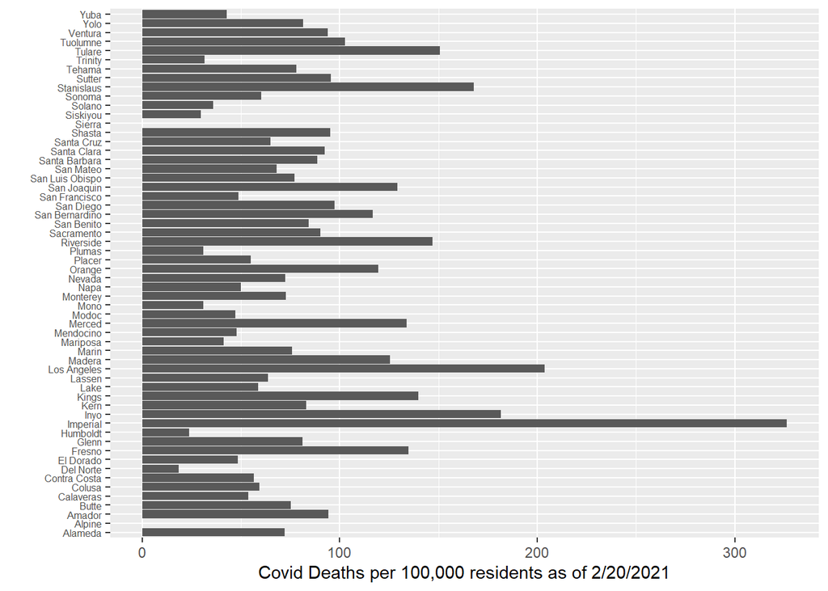

```r
# make a bar chart
ggplot(covid_point_in_time,aes(x=county,y=deaths_pc)) + geom_bar(stat='identity') + coord_flip() +
   theme(axis.text.y=element_text(size=6)) + ylab("Covid Deaths per 100,000 residents as of 2/20/2021") +
  xlab("")
```

In order to make a map, we need to fortify the spatial data object `ca_counties` with the covid data.

```r
# join the covid rates to the county boundaries
ca_counties <- ca_counties %>% left_join(covid_point_in_time,by=c("NAME"="county"))

# make some breaks to make the map look nicer
quantile(ca_counties$deaths_pc,probs=c(0.25,0.5,0.75,0.9,na.rm=T))
```

```
##       25%       50%       75%       90%      100%
##  49.02409  75.51404  96.83786 141.97657 326.22137
```

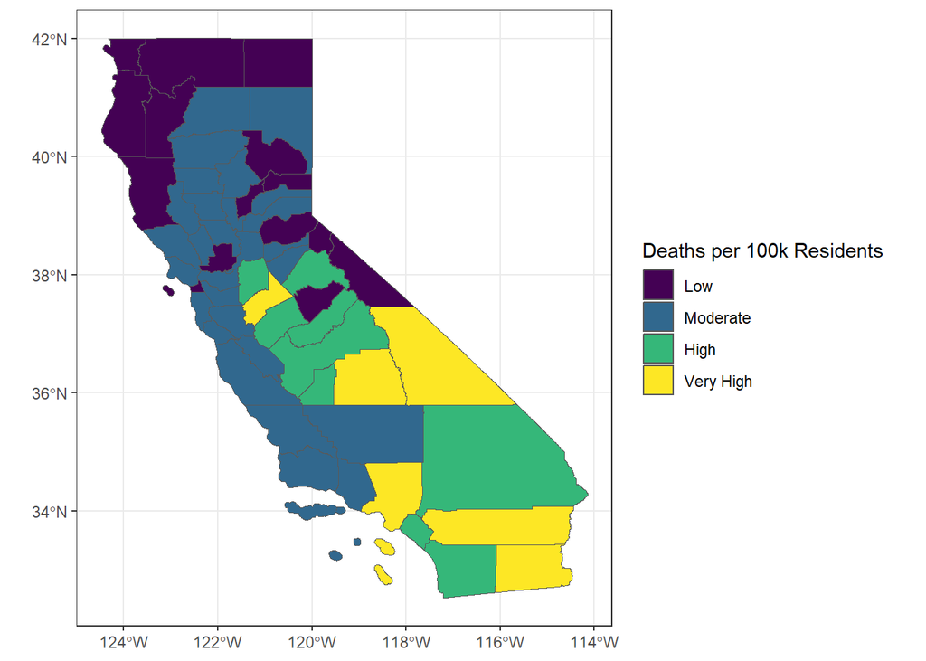

```r
ca_counties <- ca_counties %>% mutate(covid_death_rate=ifelse(deaths_pc<49,"Low",
                                                       ifelse(deaths_pc>=49 & deaths_pc<96,"Moderate",
                                                       ifelse(deaths_pc>=96 & deaths_pc<141,"High",
                                                       ifelse(deaths_pc>=141,"Very High",NA))))) %>%
                mutate(covid_death_rate=factor(covid_death_rate,levels=c("Low","Moderate","High","Very High")))

# make the map
ggplot(ca_counties) + geom_sf(aes(fill=covid_death_rate)) + scale_fill_viridis_d(name="Deaths per 100k Residents") + theme_bw()
```